# Bellabeat Case Study

Marshall Tolleson

2025-08-13

# Bellabeat Marketing Guidance

### A case study for the Grow with Google Data Analytics certificate

## Introduction

The executive and marketing teams of Bellabeat, a fitness device company, would like to analyze usage for fitness trackers in general to guide their future marketing efforts. They have a suite of fitness products available and want to know how publicly available data might help guide how they market some of their devices or subscription. They have provided a dataset sourced from Kaggle user Mobius which details user data from 33 distinct users including heart rate, activity intensity, and sleep data.

This report will identify which features were most used on the fitness trackers,and any discernible habits from the individuals included in the dataset. After analysis, inferences will be made about which Bellabeat products these results would be most compatible with, and how these insights might guide the marketing team in their future strategic campaigns.

## Data Preparation

The dataset, titled “FitBit Fitness Tracker Data” available at https://www.kaggle.com/datasets/arashnic/fitbit was generated by voluntary responses to an Amazon Mechanical Turk survey in 2016. Participants consented to submit their personal tracker data, and access to this data is under a CC0:Public Domain license. The dataset includes 18 tables which have been summarized in 2 tables, one for daily activity and one for sleep only. Analysis of the summary tables will give insight into which features common to fitness tracking devices are being used by the survey participants and their general fitness levels. The sex of the participants is not listed in the data, which may hamper interpretation and application for Bellabeat since their products are designed for women.

The data are mostly clean, but there are obvious typographical errors (such as input of “50” calories in a day from a user who averaged 1500) that would skew summary statistics, so these have been removed. Some “dirty data” values have been retained to allow for “usage” analysis, i.e. a participant may have logged calories only for one day but not their activity. Data cleaning was carried out in Microsoft Excel.

## Analysis

### Feature Usage

It is easy to determine how many participants logged any activity including steps, a workout, or calories, by checking for distinct values in the ID column. We can do the same for the sleep summary table to see how many users used their device to log sleep.

```r
distinct_count_activity <- length(unique((dailyActivity_merged$Id)))
print(distinct_count_activity)
```

```
## [1] 33
```

```r
distinct_count_sleep <- length(unique((sleepDay_merged$Id)))
print(distinct_count_sleep)
```

```
## [1] 24
```

Every survey participant used their fitness device to log some activity, however nearly one third of survey participants did not use their device to track their sleep.

Even though each participant used their devices to log activities, a preliminary glance at the data reveal that not every participant used every feature. To determine how many participants used each feature, we can set up a table that summarizes the average value for each participant in each column:

```r
mean_table <- dailyActivity_merged %>%
  group_by(Id) %>%
  summarise(across(2:14, ~ mean(.x, na.rm=F))) %>%
  select(1:5,13,14)
print(mean_table, n=33)
```

```
## # A tibble: 33 × 7
##            Id TotalSteps TotalDistance TrackerDistance LoggedActivitiesDistance
##         <dbl>      <dbl>         <dbl>           <dbl>                    <dbl>
##  1 1503960366     12117.         7.81            7.81                    0
##  2 1624580081      5744.         3.91            3.91                    0
##  3 1644430081      7283.         5.30            5.30                    0
##  4 1844505072      2580.         1.71            1.71                    0
##  5 1927972279       916.         0.635           0.635                   0
##  6 2022484408     11371.         8.08            8.08                    0
##  7 2026352035      5567.         3.45            3.45                    0
##  8 2320127002      4717.         3.19            3.19                    0
##  9 2347167796     10077.         6.73            6.73                    0
## 10 2873212765      7556.         5.10            5.10                    0
## 11 3372868164      6862.         4.71            4.71                    0
## 12 3977333714     11338.         7.76            7.76                    0
```

[output cut: 22 more lines]

This table shows us several things, intended and otherwise. First, only 4 of the 33 participants are using their devices to log activity distances. Second, there may be some discrepancies in the data since several users are averaging greater than 15 sedentary hours a day and are not logging their activity distance, but are logging greater than 10 miles traveled each day with a corresponding large number of steps. Either these individuals are training for distance race without using their fitness device as a training aid (not logging their workout distance) or the fitness tracker is counting distance traveled in a vehicle as walked miles. By calculating their miles per hour by dividing the “Very Active Distance” value by the “Very Active Minutes” value for each day, the data suggest these individuals were able to maintain a 6 min/mile pace or faster for multiple hours each day, which would make them world class marathoners. It is more likely that the fitness device was not functioning properly.

### User Profile

Bellabeat may also be interested in the habits of the average fitness device user according to these data. A summary table for the average value of each feature is below:

```r
selected_features <- dailyActivity_merged %>%
  select(3:5, 14, 15)

selected_means <- selected_features %>%
  summarise(across(1:5, ~ mean(.x, na.rm = F)))
print(selected_means)
```

```
##   TotalSteps TotalDistance TrackerDistance SedentaryMinutes Calories
## 1   7669.691      5.512585        5.498173         995.3793 2312.632
```

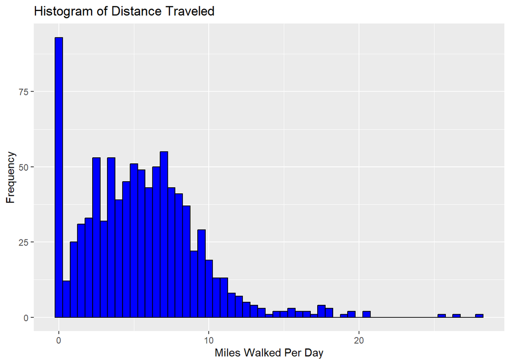

## Discussion and Recommendations

These data align most accurately with the “Leaf” and “Time” wearable devices. These devices track user activity similar to that listed in the above dataset and analysis. According to that analysis, the following approaches are recommended for future marketing efforts:

For the Moderate Activity User

- These users are much like the Low Activity User, except that they are more likely to be monitoring their results and may be more receptive to useful features in the app. Features like goal tracking or sharing activities may even lead them to start logging their activities and would drive interaction with the app.

For the High Activity User

- These users would find value in activity logging and with more in depth analysis like what would be available with the membership subscription. Promoting your products at races or events that attract highly active people would be an effective way to be seen as a quality fitness tracking device.
- This group would also be more likely to monitor every aspect of their wellness, including sleep, so the sleep tracking functionality may be useful in a campaign targeting this group.
- Highly active users will also have higher expectations for device performance, so if Bellabeat devices are known to malfunction less, and not do things like count car rides as active distance travelled, that could be an important part of this kind of ad campaign. “Log your runs, not your car rides.”